# An example of indirect inference

Ernesto Carrella

January 27, 2017

## The basics

This is a follow-up to the [“how to fit the model”](http://carrknight.github.io/assets/oxfish/fit_example.html) demo I made right before the meeting.  
There I fit the the behaviour of the agents by comparing frequency visits at each area from data and from the agent-based model, looking for the behavioural parameters that generate the most similar histograms.

Here instead I do proper indirect inference. This was the clipart I used to explain it at our meeting in Seattle:

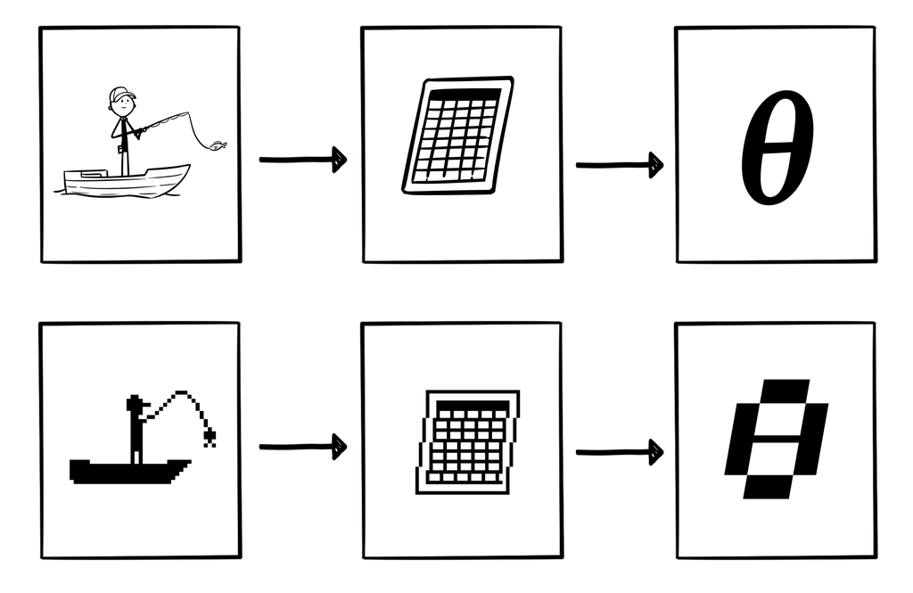

That is, just like we can take real fisher behaviour turn it into a logbook data and fit a regression to express it all in terms of logit parameter $\theta$, we can do the same on our ABM fisher and obtain a different $\hat \theta$.
Because the ABM depends on behavioural parameters $\beta$ the synthetic parameter $\hat \theta$ we generate each time we make a logbook is also a function of the behavioural parameters, that is $\hat \theta (\beta)$.
Then all we need to do is to find the behavioural parameters that minimize the *error* between synthetic and “real”:
$$\min_{\beta} \left( \theta - \hat \theta(\beta) \right)^2$$

Here as a worked example. Imagine we take the OSMOSE WFS fits by Steve for the longliners targeting groupers. That’s a relatively complicated logit with lots of parameters. I simplify that into a very simple 2 parameters logit: `habit` (which is a boolean equal to 1 if we ever visit the same spot within 90 days) and `distance` in this case straight out of port.  
There is a confusing passage here that I’ll try to explain in a different demo where I plug in Steve’s complicated logit in the model, make it run for 20 years, and then fit the simplified logit to the output and consider that to be my “real” dataset.

The end result is:

| **Parameter** | $\theta$ | Standard Error |
| --- | --- | --- |
| `habit` | 2.427440699 | 0.019854316629 |
| `distance` | -0.007528047 | 0.0001339981 |

We can now generate more synthetic data-sets with explore-exploit-imitate (or whatever) and try to minimize the distance of $\theta$ we found (where the distance is *weighted by the standard error*). That’s just another straight error minimization to feed to the Bayesian optimizer, when we do we get:

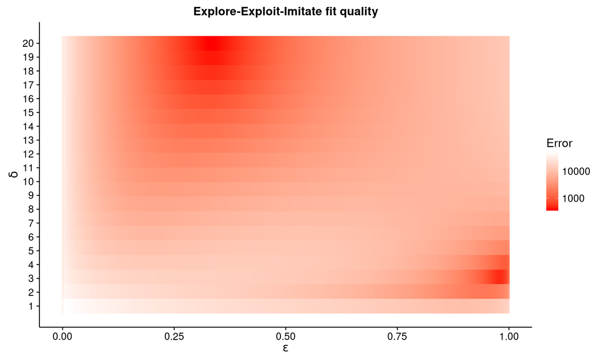

Which has two areas with low error: a moderate-explorer with large exploration range ($\epsilon=.33$, $\delta=20$) or a continuous explorer around a very circumscribed area ($\epsilon = .98$, $\delta=3$). The first has an error of about 400, the second of about 500. They generate the following parameters when fit against a logit:

| **Parameter** | Original | Moderate $\epsilon$ | High $\epsilon$ |
| --- | --- | --- | --- |
| `habit` | 2.427440699 | 2.4425309 | 2.42788360 |
| `distance` | -0.007528047 | -0.0089882 | -0.00943496 |

So that basically, for this simple logit, we can find parameters that substantially reproduce the exact same parameters as the data.  
The intersting, and worrying, bit however is that these parameters are quite different from those that matched the best histogram in the previous example. However since this OSMOSE model is still not very well parametrized on our side it might not be a problem once we get the right numbers in.

We can also compare different behavioural algorithms to see which one generates better fits. For example rather than explore-exploit-imitate we can try to use a simple bandit algorithm like $\epsilon$[-greedy](http://carrknight.github.io/assets/oxfish/algorithms.html#epsilongreedy). We can use the same discretization of Steve’s original logit and feed it to the bandit algorithm which then only depends on $\alpha$ (exponential moving average’s discount) and random exploration rate $\epsilon$. This is how the error minimization looks like:

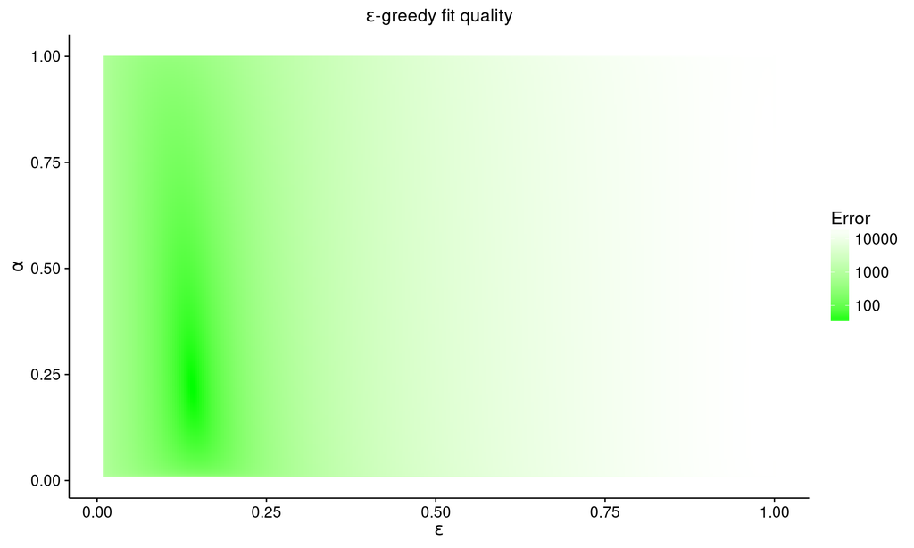

And we can rank the two algorithms as follows:

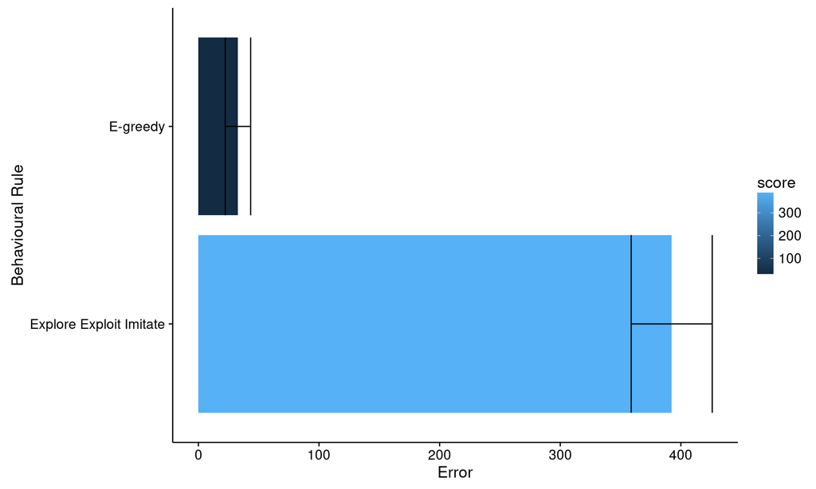

Which means that the simple bandit algorithm outperforms (when properly tuned) the explore-exploit algorithm by one order of magnitude. This makes somewhat sense since the bandit algorithm is using the “real” discretization and so ought to perform better. Notice also that we are really talking about very close fits anyway (just look at the previous table). It’s hard to argue that Explore-Exploit-Imitate is rejected by this exercise.

How much of this will be the same when OSMOSE-WFS is properly parametrized? We’ll see. The code is ready.

## Lessons learned

This exercise has shown me a few dangers of indirect inference that we’ll need to resolve at some point.

1. Logit fits must all have the same parameters but if one area is not visited, its intercept becomes NULL which means that intercepts need to go when it comes to indirect inference
2. It is possible (as here) that the parameters found by indirect inference and those found by histogram matching are very different. We need to develop a way to choose which matters the most.

Just as importantly, I think we need to spend some time with synthetic datasets like Alan mentioned to study the effects of the following:

- How informative is indirect inference when we use, like here, a “wrong” logit ?
- What is the sensitivity to the following:
  - Low number of agents
  - Low number of observations
  - Wrong discretization

A long way to go, then, but all this is doable if we allocate some time to it.